# Melvin_Project5

## Background & Context

The Thera bank recently saw a steep decline in the number of users of their credit card, credit cards are a good source of income for banks because of different kinds of fees charged by the banks like annual fees, balance transfer fees, and cash advance fees, late payment fees, foreign transaction fees, and others. Some fees are charged to every user irrespective of usage, while others are charged under specified circumstances.

Customers’ leaving credit cards services would lead bank to loss, so the bank wants to analyze the data of customers and identify the customers who will leave their credit card services and reason for same – so that bank could improve upon those areas

You as a Data scientist at Thera bank need to come up with a classification model that will help the bank improve its services so that customers do not renounce their credit cards

You need to identify the best possible model that will give the required performance

## Objective

Explore and visualize the dataset. Build a classification model to predict if the customer is going to churn or not Optimize the model using appropriate techniques Generate a set of insights and recommendations that will help the bank

## Data Dictionary:

- CLIENTNUM: Client number. Unique identifier for the customer holding the account
- Attrition_Flag: Internal event (customer activity) variable - if the account is closed then "Attrited Customer" else "Existing Customer"
- Customer_Age: Age in Years
- Gender: Gender of the account holder
- Dependent_count: Number of dependents
- Education_Level: Educational Qualification of the account holder - Graduate, High School, Unknown, Uneducated, College(refers to a college student), Post-Graduate, Doctorate.
- Marital_Status: Marital Status of the account holder
- Income_Category: Annual Income Category of the account holder
- Card_Category: Type of Card
- Months_on_book: Period of relationship with the bank
- Total_Relationship_Count: Total no. of products held by the customer
- Months_Inactive_12_mon: No. of months inactive in the last 12 months
- Contacts_Count_12_mon: No. of Contacts between the customer and bank in the last 12 months
- Credit_Limit: Credit Limit on the Credit Card
- Total_Revolving_Bal: The balance that carries over from one month to the next is the revolving balance
- Avg_Open_To_Buy: Open to Buy refers to the amount left on the credit card to use (Average of last 12 months)
- Total_Trans_Amt: Total Transaction Amount (Last 12 months)
- Total_Trans_Ct: Total Transaction Count (Last 12 months)
- Total_Ct_Chng_Q4_Q1: Ratio of the total transaction count in 4th quarter and the total transaction count in 1st quarter
- Total_Amt_Chng_Q4_Q1: Ratio of the total transaction amount in 4th quarter and the total transaction amount in 1st quarter
- Avg_Utilization_Ratio: Represents how much of the available credit the customer spent

```python
# To help with reading and manipulating data
import pandas as pd
import numpy as np

# To help with data visualization
%matplotlib inline
import matplotlib.pyplot as plt
import seaborn as sns

# To be used for missing value imputation
from sklearn.impute import SimpleImputer

# To help with model building
from sklearn.linear_model import LogisticRegression
from sklearn.tree import DecisionTreeClassifier
from sklearn.ensemble import (
    AdaBoostClassifier,
    GradientBoostingClassifier,
    RandomForestClassifier,
    BaggingClassifier,
)
from xgboost import XGBClassifier

# To get different metric scores, and split data
from sklearn import metrics
from sklearn.model_selection import train_test_split, StratifiedKFold, cross_val_score
from sklearn.metrics import (
    f1_score,
    accuracy_score,
    recall_score,
    precision_score,
    confusion_matrix,
    roc_auc_score,roc_curve,precision_recall_curve,
    plot_confusion_matrix,
)

# To be used for data scaling and one hot encoding
# from sklearn.preprocessing import StandardScaler, MinMaxScaler, OneHotEncoder

# To be used for tuning the model
from sklearn.model_selection import GridSearchCV, RandomizedSearchCV

# To be used for creating pipelines and personalizing them
from sklearn.pipeline import Pipeline
from sklearn.compose import ColumnTransformer

# To define maximum number of columns to be displayed in a dataframe
pd.set_option("display.max_columns", None)

# To supress scientific notations for a dataframe
pd.set_option("display.float_format", lambda x: "%.3f" % x)

# To supress warnings
import warnings

warnings.filterwarnings("ignore")
```

```python
#Loading dataset

data = pd.read_csv("BankChurners.csv")

data.head() # displaying the first 5 entries
```

|  | CLIENTNUM | Attrition_Flag | Customer_Age | Gender | Dependent_count | Education_Level | Marital_Status | Income_Category | Card_Category | Months_on_book | Total_Relationship_Count | Months_Inactive_12_mon | Contacts_Count_12_mon | Credit_Limit | Total_Revolving_Bal | Avg_Open_To_Buy | Total_Amt_Chng_Q4_Q1 | Total_Trans_Amt | Total_Trans_Ct | Total_Ct_Chng_Q4_Q1 | Avg_Utilization_Ratio |
| --- | --- | --- | --- | --- | --- | --- | --- | --- | --- | --- | --- | --- | --- | --- | --- | --- | --- | --- | --- | --- | --- |
| 0 | 768805383 | Existing Customer | 45 | M | 3 | High School | Married | $60K - $80K | Blue | 39 | 5 | 1 | 3 | 12691.000 | 777 | 11914.000 | 1.335 | 1144 | 42 | 1.625 | 0.061 |
| 1 | 818770008 | Existing Customer | 49 | F | 5 | Graduate | Single | Less than $40K | Blue | 44 | 6 | 1 | 2 | 8256.000 | 864 | 7392.000 | 1.541 | 1291 | 33 | 3.714 | 0.105 |
| 2 | 713982108 | Existing Customer | 51 | M | 3 | Graduate | Married | $80K - $120K | Blue | 36 | 4 | 1 | 0 | 3418.000 | 0 | 3418.000 | 2.594 | 1887 | 20 | 2.333 | 0.000 |
| 3 | 769911858 | Existing Customer | 40 | F | 4 | High School | NaN | Less than $40K | Blue | 34 | 3 | 4 | 1 | 3313.000 | 2517 | 796.000 | 1.405 | 1171 | 20 | 2.333 | 0.760 |
| 4 | 709106358 | Existing Customer | 40 | M | 3 | Uneducated | Married | $60K - $80K | Blue | 21 | 5 | 1 | 0 | 4716.000 | 0 | 4716.000 | 2.175 | 816 | 28 | 2.500 | 0.000 |

```python
data.tail()# displaying the last 5 entries
```

|  | CLIENTNUM | Attrition_Flag | Customer_Age | Gender | Dependent_count | Education_Level | Marital_Status | Income_Category | Card_Category | Months_on_book | Total_Relationship_Count | Months_Inactive_12_mon | Contacts_Count_12_mon | Credit_Limit | Total_Revolving_Bal | Avg_Open_To_Buy | Total_Amt_Chng_Q4_Q1 | Total_Trans_Amt | Total_Trans_Ct | Total_Ct_Chng_Q4_Q1 | Avg_Utilization_Ratio |
| --- | --- | --- | --- | --- | --- | --- | --- | --- | --- | --- | --- | --- | --- | --- | --- | --- | --- | --- | --- | --- | --- |
| 10122 | 772366833 | Existing Customer | 50 | M | 2 | Graduate | Single | $40K - $60K | Blue | 40 | 3 | 2 | 3 | 4003.000 | 1851 | 2152.000 | 0.703 | 15476 | 117 | 0.857 | 0.462 |
| 10123 | 710638233 | Attrited Customer | 41 | M | 2 | NaN | Divorced | $40K - $60K | Blue | 25 | 4 | 2 | 3 | 4277.000 | 2186 | 2091.000 | 0.804 | 8764 | 69 | 0.683 | 0.511 |
| 10124 | 716506083 | Attrited Customer | 44 | F | 1 | High School | Married | Less than $40K | Blue | 36 | 5 | 3 | 4 | 5409.000 | 0 | 5409.000 | 0.819 | 10291 | 60 | 0.818 | 0.000 |
| 10125 | 717406983 | Attrited Customer | 30 | M | 2 | Graduate | NaN | $40K - $60K | Blue | 36 | 4 | 3 | 3 | 5281.000 | 0 | 5281.000 | 0.535 | 8395 | 62 | 0.722 | 0.000 |
| 10126 | 714337233 | Attrited Customer | 43 | F | 2 | Graduate | Married | Less than $40K | Silver | 25 | 6 | 2 | 4 | 10388.000 | 1961 | 8427.000 | 0.703 | 10294 | 61 | 0.649 | 0.189 |

```python
df=data.copy() # copying the data
```

```python
df.head() # first 5 entries
```

|  | CLIENTNUM | Attrition_Flag | Customer_Age | Gender | Dependent_count | Education_Level | Marital_Status | Income_Category | Card_Category | Months_on_book | Total_Relationship_Count | Months_Inactive_12_mon | Contacts_Count_12_mon | Credit_Limit | Total_Revolving_Bal | Avg_Open_To_Buy | Total_Amt_Chng_Q4_Q1 | Total_Trans_Amt | Total_Trans_Ct | Total_Ct_Chng_Q4_Q1 | Avg_Utilization_Ratio |
| --- | --- | --- | --- | --- | --- | --- | --- | --- | --- | --- | --- | --- | --- | --- | --- | --- | --- | --- | --- | --- | --- |
| 0 | 768805383 | Existing Customer | 45 | M | 3 | High School | Married | $60K - $80K | Blue | 39 | 5 | 1 | 3 | 12691.000 | 777 | 11914.000 | 1.335 | 1144 | 42 | 1.625 | 0.061 |
| 1 | 818770008 | Existing Customer | 49 | F | 5 | Graduate | Single | Less than $40K | Blue | 44 | 6 | 1 | 2 | 8256.000 | 864 | 7392.000 | 1.541 | 1291 | 33 | 3.714 | 0.105 |
| 2 | 713982108 | Existing Customer | 51 | M | 3 | Graduate | Married | $80K - $120K | Blue | 36 | 4 | 1 | 0 | 3418.000 | 0 | 3418.000 | 2.594 | 1887 | 20 | 2.333 | 0.000 |
| 3 | 769911858 | Existing Customer | 40 | F | 4 | High School | NaN | Less than $40K | Blue | 34 | 3 | 4 | 1 | 3313.000 | 2517 | 796.000 | 1.405 | 1171 | 20 | 2.333 | 0.760 |
| 4 | 709106358 | Existing Customer | 40 | M | 3 | Uneducated | Married | $60K - $80K | Blue | 21 | 5 | 1 | 0 | 4716.000 | 0 | 4716.000 | 2.175 | 816 | 28 | 2.500 | 0.000 |

```python
df.info() # information about the Dtype and null values in the dataset
```

```
<class 'pandas.core.frame.DataFrame'>
RangeIndex: 10127 entries, 0 to 10126
Data columns (total 21 columns):
 #   Column                    Non-Null Count  Dtype
---  ------                    --------------  -----
 0   CLIENTNUM                 10127 non-null  int64
 1   Attrition_Flag            10127 non-null  object
 2   Customer_Age              10127 non-null  int64
 3   Gender                    10127 non-null  object
 4   Dependent_count           10127 non-null  int64
 5   Education_Level           8608 non-null   object
 6   Marital_Status            9378 non-null   object
 7   Income_Category           10127 non-null  object
 8   Card_Category             10127 non-null  object
 9   Months_on_book            10127 non-null  int64
 10  Total_Relationship_Count  10127 non-null  int64
 11  Months_Inactive_12_mon    10127 non-null  int64
 12  Contacts_Count_12_mon     10127 non-null  int64
 13  Credit_Limit              10127 non-null  float64
 14  Total_Revolving_Bal       10127 non-null  int64
 15  Avg_Open_To_Buy           10127 non-null  float64
 16  Total_Amt_Chng_Q4_Q1      10127 non-null  float64
 17  Total_Trans_Amt           10127 non-null  int64
 18  Total_Trans_Ct            10127 non-null  int64
 19  Total_Ct_Chng_Q4_Q1       10127 non-null  float64
 20  Avg_Utilization_Ratio     10127 non-null  float64
dtypes: float64(5), int64(10), object(6)
memory usage: 1.6+ MB
```

Education_Level and Marital_Status has null values, all the Data type of the columns are correct

```python
df.shape # shape of the data set
```

```
(10127, 21)
```

There are 10127 rows and 21 columns in the given data set

```python
df.duplicated().sum()# checking for duplicates
```

```
0
```

There are no duplicated entries

```python
round(df.isnull().sum() / df.isnull().count() * 100, 2)# checking for null percentage
```

```
CLIENTNUM                   0.000
Attrition_Flag              0.000
Customer_Age                0.000
Gender                      0.000
Dependent_count             0.000
Education_Level            15.000
Marital_Status              7.400
Income_Category             0.000
Card_Category               0.000
Months_on_book              0.000
Total_Relationship_Count    0.000
Months_Inactive_12_mon      0.000
Contacts_Count_12_mon       0.000
Credit_Limit                0.000
Total_Revolving_Bal         0.000
Avg_Open_To_Buy             0.000
Total_Amt_Chng_Q4_Q1        0.000
Total_Trans_Amt             0.000
Total_Trans_Ct              0.000
Total_Ct_Chng_Q4_Q1         0.000
Avg_Utilization_Ratio       0.000
dtype: float64
```

Education_Level has 15% null values and Marital_Status has 7.4% null values

```python
df.drop(["CLIENTNUM"],axis=1,inplace=True) # dropping Clientnum as it unique
```

```python
df.describe(include="all").T # to display mean,std,min,25%,50%,75% max,frequency and top
```

|  | count | unique | top | freq | mean | std | min | 25% | 50% | 75% | max |
| --- | --- | --- | --- | --- | --- | --- | --- | --- | --- | --- | --- |
| Attrition_Flag | 10127 | 2 | Existing Customer | 8500 | NaN | NaN | NaN | NaN | NaN | NaN | NaN |
| Customer_Age | 10127.000 | NaN | NaN | NaN | 46.326 | 8.017 | 26.000 | 41.000 | 46.000 | 52.000 | 73.000 |
| Gender | 10127 | 2 | F | 5358 | NaN | NaN | NaN | NaN | NaN | NaN | NaN |
| Dependent_count | 10127.000 | NaN | NaN | NaN | 2.346 | 1.299 | 0.000 | 1.000 | 2.000 | 3.000 | 5.000 |
| Education_Level | 8608 | 6 | Graduate | 3128 | NaN | NaN | NaN | NaN | NaN | NaN | NaN |
| Marital_Status | 9378 | 3 | Married | 4687 | NaN | NaN | NaN | NaN | NaN | NaN | NaN |
| Income_Category | 10127 | 6 | Less than $40K | 3561 | NaN | NaN | NaN | NaN | NaN | NaN | NaN |
| Card_Category | 10127 | 4 | Blue | 9436 | NaN | NaN | NaN | NaN | NaN | NaN | NaN |
| Months_on_book | 10127.000 | NaN | NaN | NaN | 35.928 | 7.986 | 13.000 | 31.000 | 36.000 | 40.000 | 56.000 |
| Total_Relationship_Count | 10127.000 | NaN | NaN | NaN | 3.813 | 1.554 | 1.000 | 3.000 | 4.000 | 5.000 | 6.000 |
| Months_Inactive_12_mon | 10127.000 | NaN | NaN | NaN | 2.341 | 1.011 | 0.000 | 2.000 | 2.000 | 3.000 | 6.000 |
| Contacts_Count_12_mon | 10127.000 | NaN | NaN | NaN | 2.455 | 1.106 | 0.000 | 2.000 | 2.000 | 3.000 | 6.000 |
| Credit_Limit | 10127.000 | NaN | NaN | NaN | 8631.954 | 9088.777 | 1438.300 | 2555.000 | 4549.000 | 11067.500 | 34516.000 |
| Total_Revolving_Bal | 10127.000 | NaN | NaN | NaN | 1162.814 | 814.987 | 0.000 | 359.000 | 1276.000 | 1784.000 | 2517.000 |
| Avg_Open_To_Buy | 10127.000 | NaN | NaN | NaN | 7469.140 | 9090.685 | 3.000 | 1324.500 | 3474.000 | 9859.000 | 34516.000 |
| Total_Amt_Chng_Q4_Q1 | 10127.000 | NaN | NaN | NaN | 0.760 | 0.219 | 0.000 | 0.631 | 0.736 | 0.859 | 3.397 |
| Total_Trans_Amt | 10127.000 | NaN | NaN | NaN | 4404.086 | 3397.129 | 510.000 | 2155.500 | 3899.000 | 4741.000 | 18484.000 |
| Total_Trans_Ct | 10127.000 | NaN | NaN | NaN | 64.859 | 23.473 | 10.000 | 45.000 | 67.000 | 81.000 | 139.000 |
| Total_Ct_Chng_Q4_Q1 | 10127.000 | NaN | NaN | NaN | 0.712 | 0.238 | 0.000 | 0.582 | 0.702 | 0.818 | 3.714 |
| Avg_Utilization_Ratio | 10127.000 | NaN | NaN | NaN | 0.275 | 0.276 | 0.000 | 0.023 | 0.176 | 0.503 | 0.999 |

- Most common customer type is Existing
- Most common Gender is Female
- Most common Education level is Graduate
- Most common Marital Status is Married
- Most common Income Category is Less than $40K
- Most common Card Category is Blue
- Most of the customers are aged between 26-73 with a mean of 46
- Most of the customers have a Revolving Balance between 0-2517 with a mean of 1162
- Most of the customers have a credit limit between 1438-34516 with a mean of 8632

## Filling null values

```python
df["Marital_Status"].fillna("Married", inplace=True)
```

As most of the customers ares Married

```python
df["Education_Level"].fillna("Graduate", inplace=True)
```

As most of the customers are seen to be Graduates

```python
round(df.isnull().sum() / df.isnull().count() * 100, 2) # checking if there are any null values
```

```
Attrition_Flag             0.000
Customer_Age               0.000
Gender                     0.000
Dependent_count            0.000
Education_Level            0.000
Marital_Status             0.000
Income_Category            0.000
Card_Category              0.000
Months_on_book             0.000
Total_Relationship_Count   0.000
Months_Inactive_12_mon     0.000
Contacts_Count_12_mon      0.000
Credit_Limit               0.000
Total_Revolving_Bal        0.000
Avg_Open_To_Buy            0.000
Total_Amt_Chng_Q4_Q1       0.000
Total_Trans_Amt            0.000
Total_Trans_Ct             0.000
Total_Ct_Chng_Q4_Q1        0.000
Avg_Utilization_Ratio      0.000
dtype: float64
```

We see that all the columns have 0% in null values

```python
# Find the counts of all the different unique values  in each columns
cat_cols=['Attrition_Flag','Gender','Dependent_count','Education_Level','Marital_Status','Income_Category','Card_Category','Months_on_book','Total_Relationship_Count','Months_Inactive_12_mon','Contacts_Count_12_mon','Credit_Limit','Avg_Open_To_Buy','Total_Amt_Chng_Q4_Q1','Total_Trans_Amt','Total_Trans_Ct','Total_Ct_Chng_Q4_Q1','Avg_Utilization_Ratio']

for column in cat_cols:
    print(data[column].value_counts())
    print('-'*30)
```

```
Existing Customer    8500
Attrited Customer    1627
Name: Attrition_Flag, dtype: int64
------------------------------
F    5358
M    4769
Name: Gender, dtype: int64
------------------------------
3    2732
2    2655
1    1838
4    1574
0     904
5     424
Name: Dependent_count, dtype: int64
------------------------------
Graduate         3128
High School      2013
Uneducated       1487
College          1013
Post-Graduate     516
Doctorate         451
Name: Education_Level, dtype: int64
------------------------------
Married     4687
Single      3943
Divorced     748
Name: Marital_Status, dtype: int64
------------------------------
Less than $40K    3561
$40K - $60K       1790
$80K - $120K      1535
$60K - $80K       1402
abc               1112
$120K +            727
Name: Income_Category, dtype: int64
------------------------------
Blue        9436
Silver       555
Gold         116
```

[output cut: 151 more lines]

```
Name: Total_Ct_Chng_Q4_Q1, Length: 830, dtype: int64
------------------------------
0.000    2470
0.073      44
0.057      33
0.048      32
0.060      30
         ...
0.929       1
0.874       1
0.995       1
0.011       1
0.985       1
Name: Avg_Utilization_Ratio, Length: 964, dtype: int64
------------------------------
```

We see that all the columns seem to be inputed correctly however in Income_Category we see the entry "abc" which has to be changed

```python
df["Income_Category"] = df["Income_Category"].replace("abc", "Less than $40K")# Changing abc to the most frequent value  i.e Less than $ 40K
```

```python
df["Income_Category"].value_counts()# checking if abc has been changed
```

```
Less than $40K    4673
$40K - $60K       1790
$80K - $120K      1535
$60K - $80K       1402
$120K +            727
Name: Income_Category, dtype: int64
```

We see that Income_Category also has correct values now

## Univariate Analysis

```python
# While doing uni-variate analysis of numerical variables we want to study their central tendency and dispersion.
def histogram_boxplot(feature, figsize=(15,10), bins = None):
    """ Boxplot and histogram combined
    feature: 1-d feature array
    figsize: size of fig (default (9,8))
    bins: number of bins (default None / auto)
    """
    f2, (ax_box2, ax_hist2) = plt.subplots(nrows = 2, # Number of rows of the subplot grid= 2
                                           sharex = True, # x-axis will be shared among all subplots
                                           gridspec_kw = {"height_ratios": (.25, .75)},
                                           figsize = figsize
                                           ) # creating the 2 subplots
    sns.boxplot(feature, ax=ax_box2, showmeans=True, color='red') # boxplot will be created and a star will indicate the mean value of the column
    sns.distplot(feature, kde=F, ax=ax_hist2, bins=bins,color = 'blue') if bins else sns.distplot(feature, kde=False, ax=ax_hist2,color='tab:cyan') # For histogram
    ax_hist2.axvline(np.mean(feature), color='violet', linestyle='--') #  mean to the histogram
    ax_hist2.axvline(np.median(feature), color='black', linestyle='-') #  median to the histogram
```

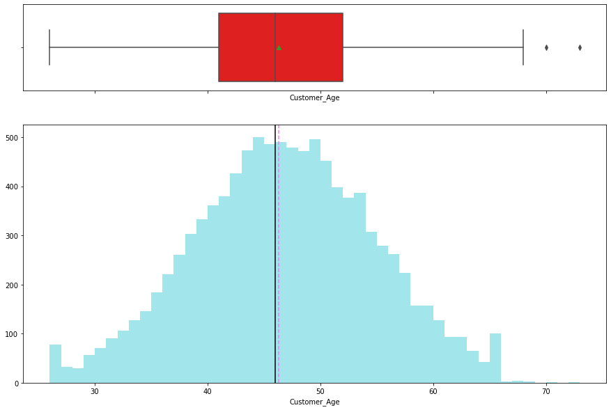

```python
histogram_boxplot(df['Customer_Age'])
```

- Mean age of the customers are about 46 years
- Mean and Median are clost to each other so the age is well distributed

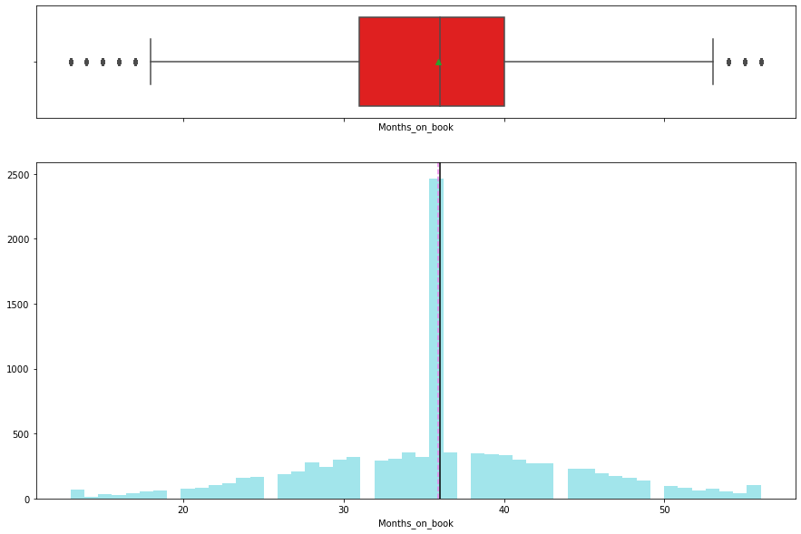

```python
histogram_boxplot(df['Months_on_book'])
```

- Most of the Months_on_books are about 36
- There are very few outliers

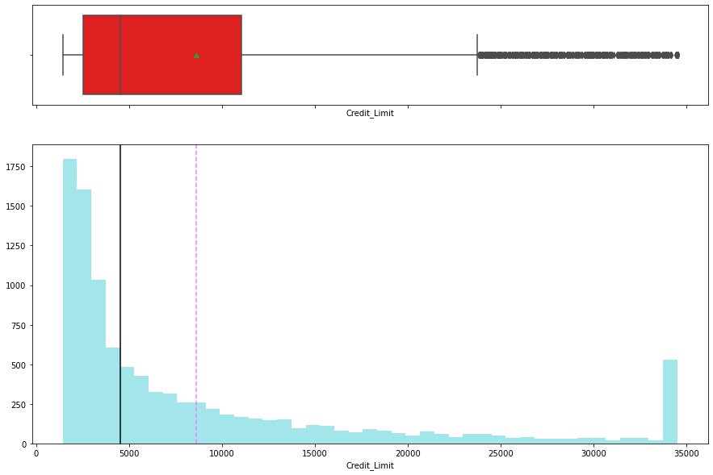

```python
histogram_boxplot(df['Credit_Limit'])
```

- The data is Right skewed
- There are many outliers

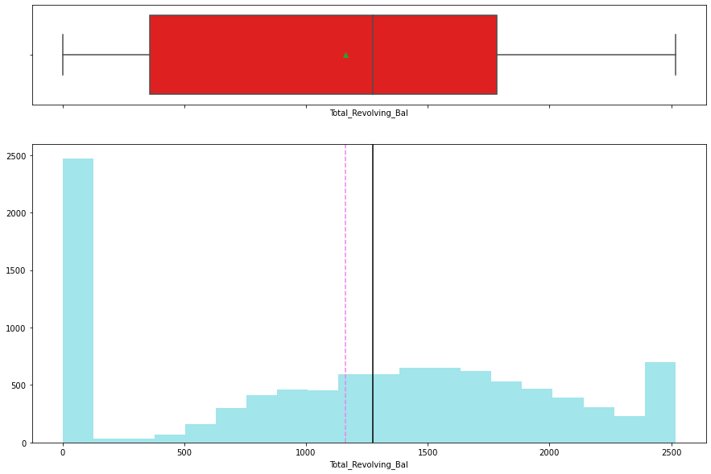

```python
histogram_boxplot(df['Total_Revolving_Bal'])
```

There are a lot of customers with 0 balance

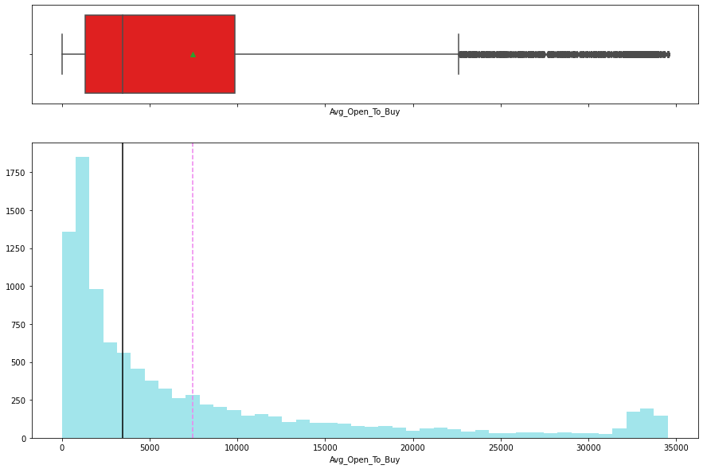

```python
histogram_boxplot(df['Avg_Open_To_Buy'])
```

- The data is Right skewed
- There are many outliers

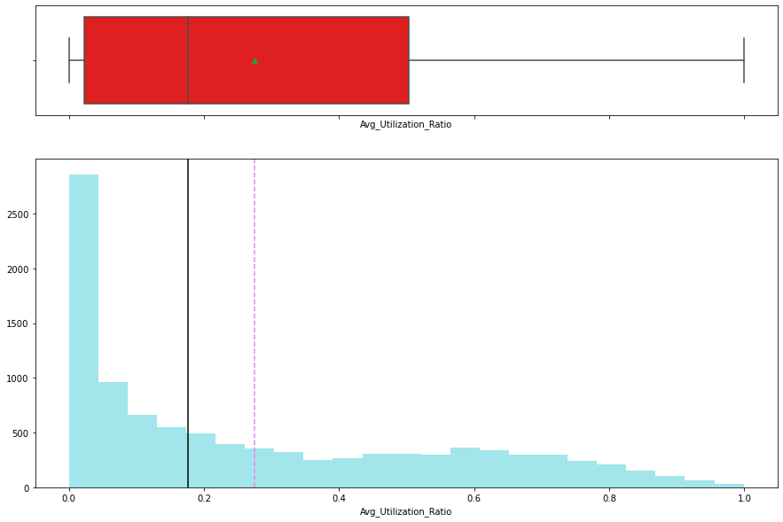

```python
histogram_boxplot(df['Avg_Utilization_Ratio'])
```

- The data is Right skewed

```python
# Function to create barplots that indicate percentage for each category.

def perc_on_bar(z):

    total = len(df[z]) # length of the column
    plt.figure(figsize=(15,5))
    ax = sns.countplot(df[z],palette='Paired')
    for p in ax.patches:
        percentage = '{:.1f}%'.format(100 * p.get_height()/total) # percentage of each class of the category
        x = p.get_x() + p.get_width() / 2 - 0.05 # width of the plot
        y = p.get_y() + p.get_height()           # hieght of the plot

        ax.annotate(percentage, (x, y), size = 12) # annotate the percantage
    plt.show() # show the plot
```

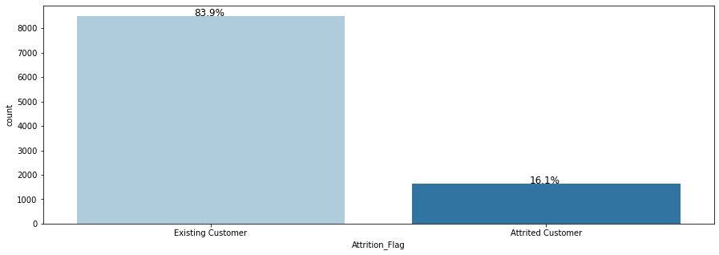

```python
perc_on_bar('Attrition_Flag')
```

Existing customers are the most in the data set i.e 83.9%

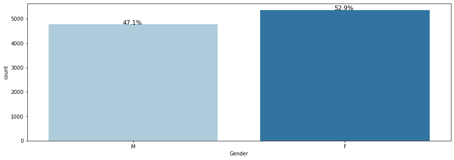

```python
perc_on_bar('Gender')
```

Females are more than Males in the dataset i.e 52.9% and 47.1% respectively

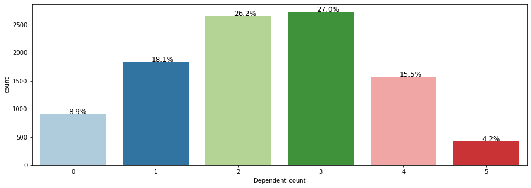

```python
perc_on_bar('Dependent_count')
```

Most of the customers have 2-3 dependants which make about 26.2-27% of the customers respectively

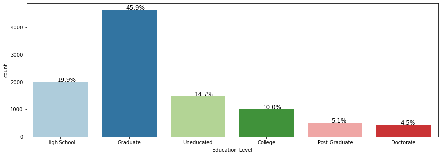

```python
perc_on_bar('Education_Level')
```

Most of the customers are Graduates i.e 45.9%

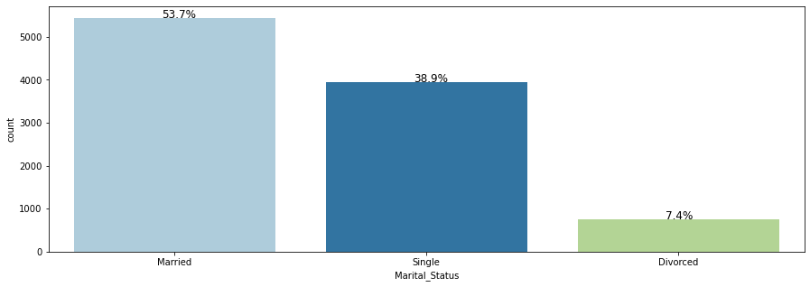

```python
perc_on_bar('Marital_Status')
```

Most of the Customers are married (53.7%)

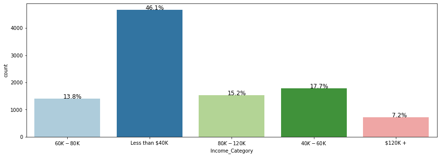

```python
perc_on_bar('Income_Category')
```

most of the customers make less than $40K (46.1%)

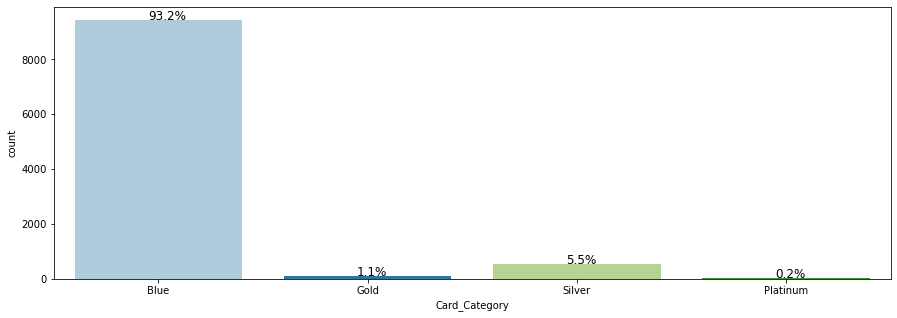

```python
perc_on_bar('Card_Category')
```

Most of the customers use Blue Card (93.2%)

## Changing Attrition and Existing to 0 and 1

As our focus is on Attrition customers we can change them to 1 and Existing customers to 0

```python
df["Attrition_Flag"] = df["Attrition_Flag"].replace("Attrited Customer", 1)
```

```python
df["Attrition_Flag"] = df["Attrition_Flag"].replace("Existing Customer", 0)
```

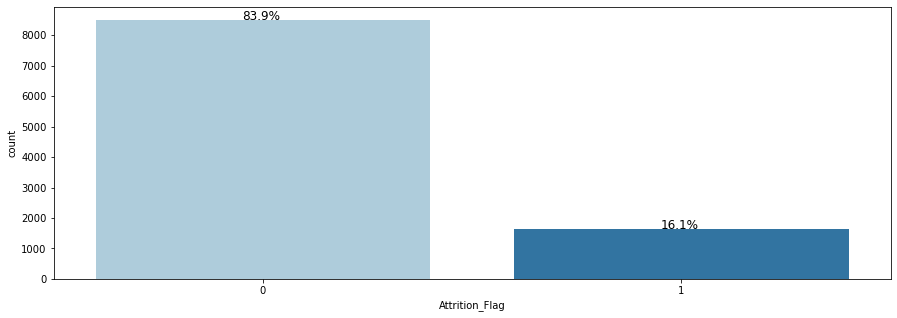

```python
perc_on_bar('Attrition_Flag')# checking if the percentages have changed after changing to 1 and 0
```

There is no change in the values so all the values have been assigned correctly

## Bivariate Analysis

```python
df.corr() # finding correlations
```

|  | Attrition_Flag | Customer_Age | Dependent_count | Months_on_book | Total_Relationship_Count | Months_Inactive_12_mon | Contacts_Count_12_mon | Credit_Limit | Total_Revolving_Bal | Avg_Open_To_Buy | Total_Amt_Chng_Q4_Q1 | Total_Trans_Amt | Total_Trans_Ct | Total_Ct_Chng_Q4_Q1 | Avg_Utilization_Ratio |
| --- | --- | --- | --- | --- | --- | --- | --- | --- | --- | --- | --- | --- | --- | --- | --- |
| Attrition_Flag | 1.000 | 0.018 | 0.019 | 0.014 | -0.150 | 0.152 | 0.204 | -0.024 | -0.263 | -0.000 | -0.131 | -0.169 | -0.371 | -0.290 | -0.178 |
| Customer_Age | 0.018 | 1.000 | -0.122 | 0.789 | -0.011 | 0.054 | -0.018 | 0.002 | 0.015 | 0.001 | -0.062 | -0.046 | -0.067 | -0.012 | 0.007 |
| Dependent_count | 0.019 | -0.122 | 1.000 | -0.103 | -0.039 | -0.011 | -0.041 | 0.068 | -0.003 | 0.068 | -0.035 | 0.025 | 0.050 | 0.011 | -0.037 |
| Months_on_book | 0.014 | 0.789 | -0.103 | 1.000 | -0.009 | 0.074 | -0.011 | 0.008 | 0.009 | 0.007 | -0.049 | -0.039 | -0.050 | -0.014 | -0.008 |
| Total_Relationship_Count | -0.150 | -0.011 | -0.039 | -0.009 | 1.000 | -0.004 | 0.055 | -0.071 | 0.014 | -0.073 | 0.050 | -0.347 | -0.242 | 0.041 | 0.068 |
| Months_Inactive_12_mon | 0.152 | 0.054 | -0.011 | 0.074 | -0.004 | 1.000 | 0.029 | -0.020 | -0.042 | -0.017 | -0.032 | -0.037 | -0.043 | -0.039 | -0.008 |
| Contacts_Count_12_mon | 0.204 | -0.018 | -0.041 | -0.011 | 0.055 | 0.029 | 1.000 | 0.021 | -0.054 | 0.026 | -0.024 | -0.113 | -0.152 | -0.095 | -0.055 |
| Credit_Limit | -0.024 | 0.002 | 0.068 | 0.008 | -0.071 | -0.020 | 0.021 | 1.000 | 0.042 | 0.996 | 0.013 | 0.172 | 0.076 | -0.002 | -0.483 |
| Total_Revolving_Bal | -0.263 | 0.015 | -0.003 | 0.009 | 0.014 | -0.042 | -0.054 | 0.042 | 1.000 | -0.047 | 0.058 | 0.064 | 0.056 | 0.090 | 0.624 |
| Avg_Open_To_Buy | -0.000 | 0.001 | 0.068 | 0.007 | -0.073 | -0.017 | 0.026 | 0.996 | -0.047 | 1.000 | 0.008 | 0.166 | 0.071 | -0.010 | -0.539 |
| Total_Amt_Chng_Q4_Q1 | -0.131 | -0.062 | -0.035 | -0.049 | 0.050 | -0.032 | -0.024 | 0.013 | 0.058 | 0.008 | 1.000 | 0.040 | 0.005 | 0.384 | 0.035 |
| Total_Trans_Amt | -0.169 | -0.046 | 0.025 | -0.039 | -0.347 | -0.037 | -0.113 | 0.172 | 0.064 | 0.166 | 0.040 | 1.000 | 0.807 | 0.086 | -0.083 |
| Total_Trans_Ct | -0.371 | -0.067 | 0.050 | -0.050 | -0.242 | -0.043 | -0.152 | 0.076 | 0.056 | 0.071 | 0.005 | 0.807 | 1.000 | 0.112 | 0.003 |
| Total_Ct_Chng_Q4_Q1 | -0.290 | -0.012 | 0.011 | -0.014 | 0.041 | -0.039 | -0.095 | -0.002 | 0.090 | -0.010 | 0.384 | 0.086 | 0.112 | 1.000 | 0.074 |
| Avg_Utilization_Ratio | -0.178 | 0.007 | -0.037 | -0.008 | 0.068 | -0.008 | -0.055 | -0.483 | 0.624 | -0.539 | 0.035 | -0.083 | 0.003 | 0.074 | 1.000 |

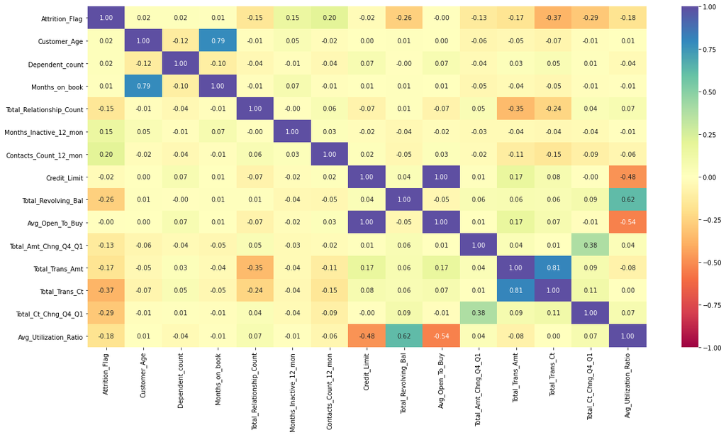

```python
plt.figure(figsize=(20,10))
sns.heatmap(df.corr(), annot=True, vmin=-1, vmax=1, fmt=".2f", cmap="Spectral" )
plt.show()
```

- Attrition_Flag is negatively related to Total_Trans_Ct (-0.37)
- Attrition_Flag is negatively related to Total_ct_Chng_Q4_Q1 (-0.29)
- Attrition_Flag is negatively related to Total_Revolving_Bal (-0.26)
- Attrition_Flag is negatively related to Avg_Utilization_Ratio (-0.18)
- Attrition_Flag is positively related to Contacts_Count_12_mon (0.20)
- Avg_Utilization_Ratio is negatively related to Credit_Limit and Avg_Open_To_Buy by -0.48 and -0.54 respectively
- Avg_Utilization_Ratio is positively related to Total_Revolving_Bal by 0.62
- Avg_Open_To_Buy has a strong postive relation to Credit_Limit

## Multivariate Analysis

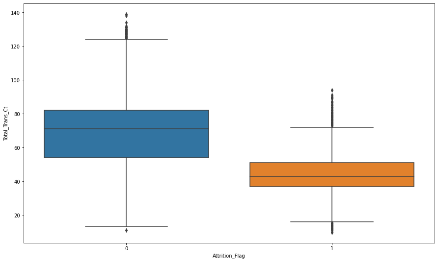

```python
plt.figure(figsize=(15, 9))
sns.boxplot(x="Attrition_Flag", y="Total_Trans_Ct", data=df)
```

Most of the Attrited customers have a lower Total Transaction count

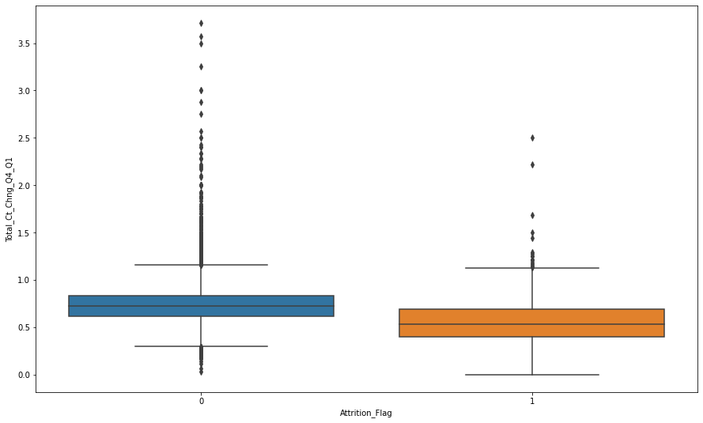

```python
plt.figure(figsize=(15, 9))
sns.boxplot(x="Attrition_Flag", y="Total_Ct_Chng_Q4_Q1", data=df)
```

Attrited customers have a slightly lower Total_Ct_Chng_Q4_Q1 ,however there are few outliers

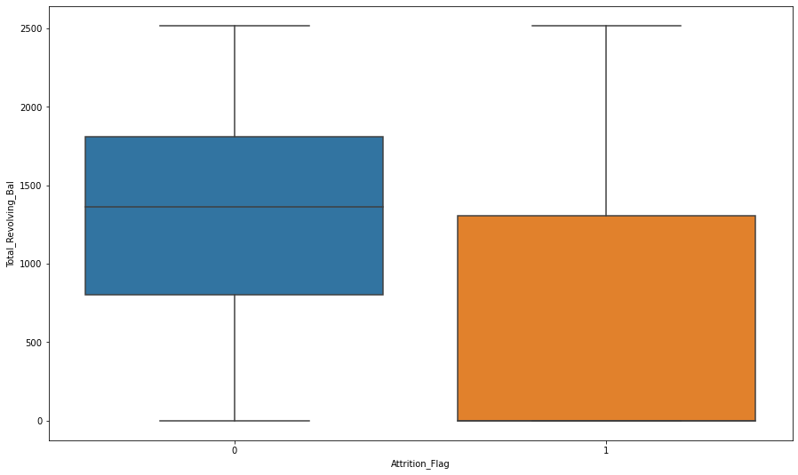

```python
plt.figure(figsize=(15, 9))
sns.boxplot(x="Attrition_Flag", y="Total_Revolving_Bal", data=df)
```

Attrited customers have a lower total revolving balance

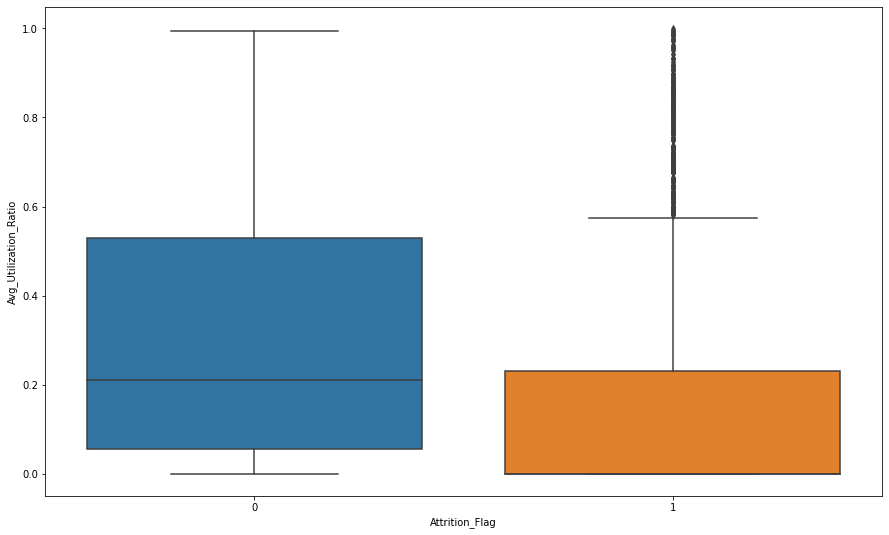

```python
plt.figure(figsize=(15, 9))
sns.boxplot(x="Attrition_Flag", y="Avg_Utilization_Ratio", data=df)
```

Attrited customers have a lower average utilization ratio

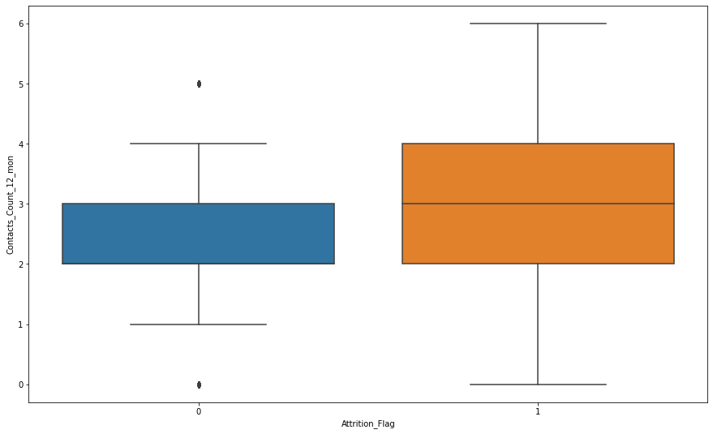

```python
plt.figure(figsize=(15, 9))
sns.boxplot(x="Attrition_Flag", y="Contacts_Count_12_mon", data=df)
```

Attrited customers have a higher contactd count in 12 months

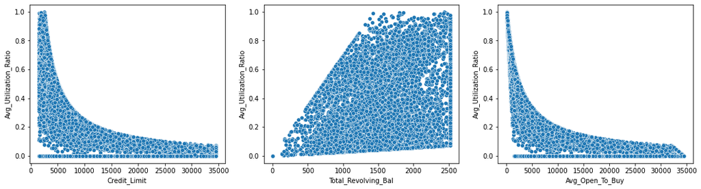

```python
corr_cols = ['Credit_Limit','Total_Revolving_Bal','Avg_Open_To_Buy']


plt.figure(figsize=(18,15))

pos = 1

for i in corr_cols:
    plt.subplot(3, 3, pos)

    if i!='Avg_Utilization_Ratio':

        sns.scatterplot(data=df, x=i, y="Avg_Utilization_Ratio")


        pos += 1
```

- Credit Limit is right skewed
- Aerage open to buy is right skewed
- Total revolving Balance increases as average utilization ration increases

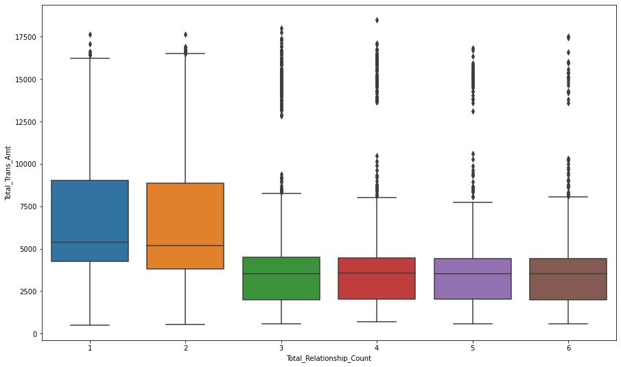

```python
plt.figure(figsize=(15, 9))
sns.boxplot(x="Total_Relationship_Count", y="Total_Trans_Amt", data=df)
```

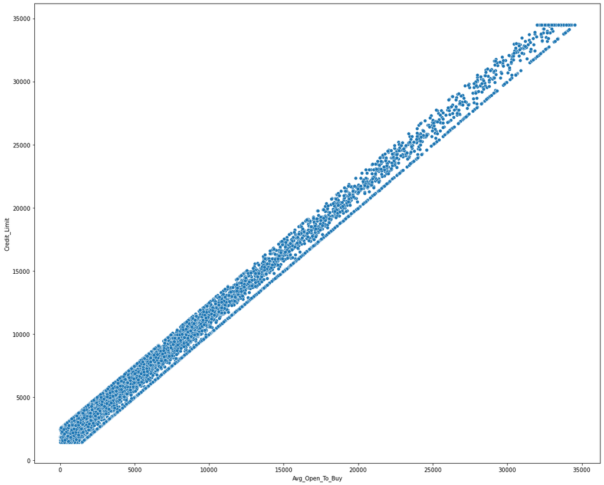

```python
plt.figure(figsize=(18,15))
sns.scatterplot(data=df, x="Avg_Open_To_Buy", y="Credit_Limit")
```

As credit limit increase Avg_open_To_Buy also increases linearly

```python
### Function to plot stacked bar charts for categorical columns
def stacked_plot(x):
    sns.set()
    ## crosstab
    tab1 = pd.crosstab(x,df['Attrition_Flag'],margins=True).sort_values(by=1,ascending=False)
    print(tab1)
    print('-'*120)
    ## visualising the cross tab
    tab = pd.crosstab(x,df['Attrition_Flag'],normalize='index').sort_values(by=1,ascending=False)
    tab.plot(kind='bar',stacked=True,figsize=(17,7))
    plt.legend(loc='lower left', frameon=False,)
    plt.legend(loc="upper left", bbox_to_anchor=(1,1))
    plt.show()
```

## Attrition VS Gender

```
Attrition_Flag     0     1    All
Gender
All             8500  1627  10127
F               4428   930   5358
M               4072   697   4769
------------------------------------------------------------------------------------------------------------------------
```

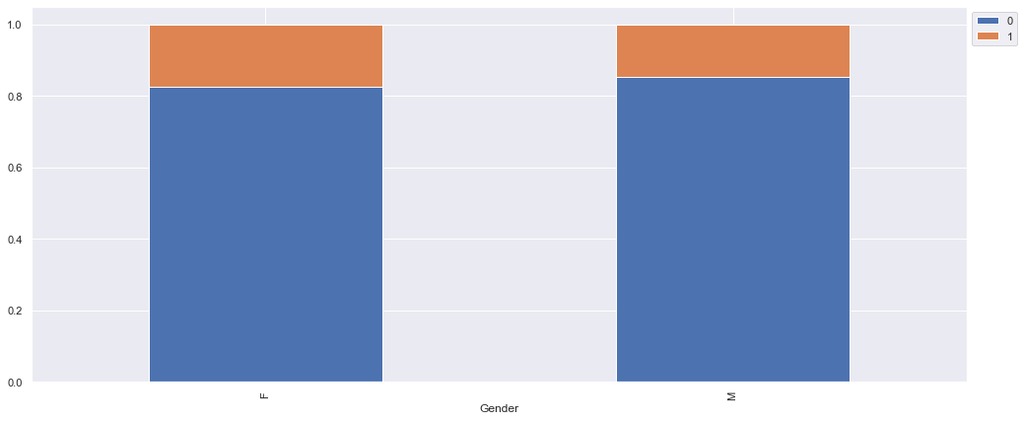

```python
stacked_plot(data['Gender'])
```

Most of the Attrited customers are Females

## Attrition VS Education Level

```
Attrition_Flag      0     1   All
Education_Level
All              7237  1371  8608
Graduate         2641   487  3128
High School      1707   306  2013
Uneducated       1250   237  1487
College           859   154  1013
Doctorate         356    95   451
Post-Graduate     424    92   516
------------------------------------------------------------------------------------------------------------------------
```

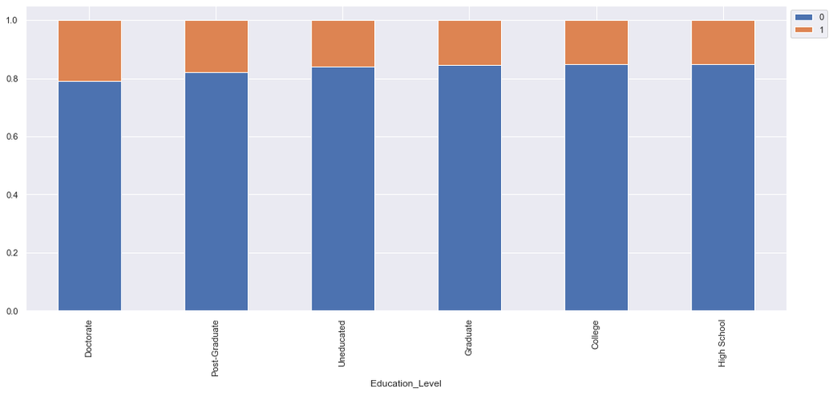

```python
stacked_plot(data['Education_Level'])
```

Customers having Doctrates have attrited the most

## Attrition VS Marital Status

```
Attrition_Flag     0     1   All
Marital_Status
All             7880  1498  9378
Married         3978   709  4687
Single          3275   668  3943
Divorced         627   121   748
------------------------------------------------------------------------------------------------------------------------
```

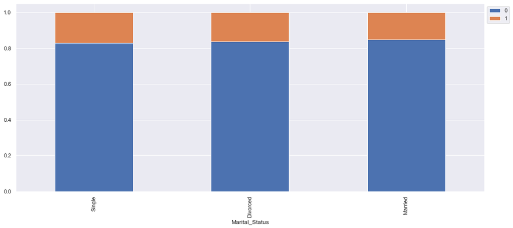

```python
stacked_plot(data['Marital_Status'])
```

Single and Divorced customers have attrited the most

## Attrition VS Income Category

```
Attrition_Flag      0     1    All
Income_Category
All              8500  1627  10127
Less than $40K   2949   612   3561
$40K - $60K      1519   271   1790
$80K - $120K     1293   242   1535
$60K - $80K      1213   189   1402
abc               925   187   1112
$120K +           601   126    727
------------------------------------------------------------------------------------------------------------------------
```

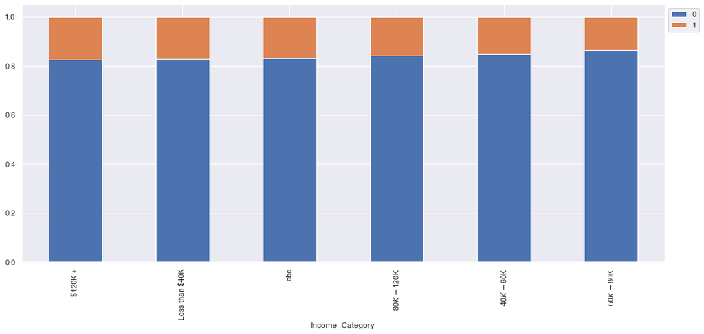

```python
stacked_plot(data['Income_Category'])
```

Customers having more than $ 120k and less than $ 40K are most likely to Attrite

## Attrition VS Card Category

```
Attrition_Flag     0     1    All
Card_Category
All             8500  1627  10127
Blue            7917  1519   9436
Silver           473    82    555
Gold              95    21    116
Platinum          15     5     20
------------------------------------------------------------------------------------------------------------------------
```

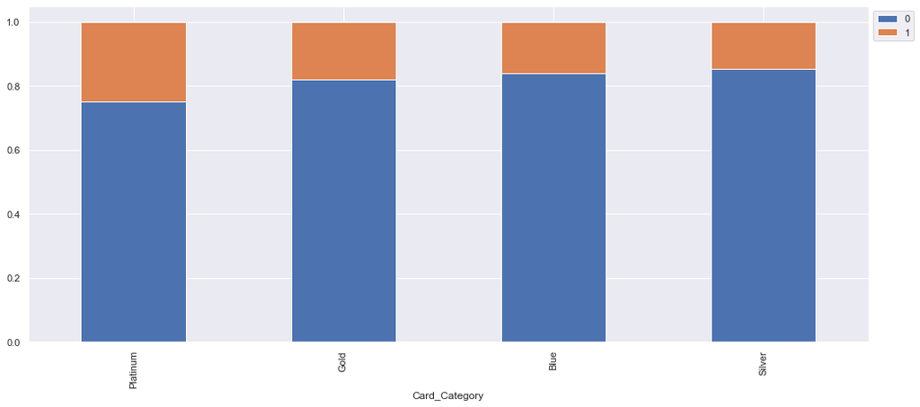

```python
stacked_plot(data['Card_Category'])
```

Customers having Platinum card are most likely to attrite

## Finding the Outliers

```python
Q1 = data.quantile(0.25)             #To find the 25th percentile and 75th percentile.
Q3 = data.quantile(0.75)

IQR = Q3 - Q1                           #Inter Quantile Range (75th perentile - 25th percentile)

lower=Q1-1.5*IQR                        #Finding lower and upper bounds for all values. All values outside these bounds are outliers
upper=Q3+1.5*IQR
```

```python
((df.select_dtypes(include=['float64','int64'])<lower) | (df.select_dtypes(include=['float64','int64'])>upper)).sum()/len(df)*100
```

```
Attrition_Flag             0.000
Avg_Open_To_Buy            9.509
Avg_Utilization_Ratio      0.000
CLIENTNUM                  0.000
Contacts_Count_12_mon      6.211
Credit_Limit               9.717
Customer_Age               0.020
Dependent_count            0.000
Months_Inactive_12_mon     3.268
Months_on_book             3.812
Total_Amt_Chng_Q4_Q1       3.900
Total_Ct_Chng_Q4_Q1        3.910
Total_Relationship_Count   0.000
Total_Revolving_Bal        0.000
Total_Trans_Amt            8.848
Total_Trans_Ct             0.020
dtype: float64
```

all the outliers are less than 10%

## Checking for Class Balancing

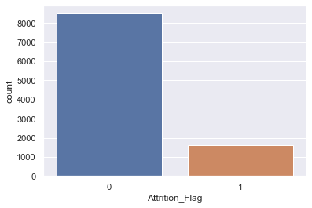

```python
sns.set(color_codes=True)
sns.countplot(df['Attrition_Flag'])
```

Existing customers are more than Attrited customers

## Creating Dummies

```python
df2=df.copy()# Creating copy of the dataset
```

```python
# Separating target variable and other variables
X = df2.drop(columns="Attrition_Flag")
X = pd.get_dummies(X, columns=['Gender','Education_Level','Income_Category','Marital_Status','Card_Category'],drop_first=True)
Y = df2["Attrition_Flag"]
```

```python
# Splitting the data into train and test sets in 70:30 ratio
X_train1, X_test1, y_train1, y_test1 = train_test_split(X, Y, test_size=0.30, random_state=1, shuffle=True)
```

```python
X_train1.shape, X_test1.shape
```

```
((7088, 29), (3039, 29))
```

## Building model

```python
def get_metrics_score(model,train,test,train_y,test_y,threshold=0.5,flag=True,roc=False):

    # defining an empty list to store train and test results

    score_list=[]

    pred_train = (model.predict_proba(train)[:,1]>threshold)
    pred_test = (model.predict_proba(test)[:,1]>threshold)

    pred_train = np.round(pred_train)
    pred_test = np.round(pred_test)

    train_acc = accuracy_score(pred_train,train_y)
    test_acc = accuracy_score(pred_test,test_y)

    train_recall = recall_score(train_y,pred_train)
    test_recall = recall_score(test_y,pred_test)

    train_precision = precision_score(train_y,pred_train)
    test_precision = precision_score(test_y,pred_test)

    train_f1 = f1_score(train_y,pred_train)
    test_f1 = f1_score(test_y,pred_test)


    score_list.extend((train_acc,test_acc,train_recall,test_recall,train_precision,test_precision,train_f1,test_f1))


    if flag == True:
        print("Accuracy on training set : ",accuracy_score(pred_train,train_y))
        print("Accuracy on test set : ",accuracy_score(pred_test,test_y))
        print("Recall on training set : ",recall_score(train_y,pred_train))
        print("Recall on test set : ",recall_score(test_y,pred_test))
        print("Precision on training set : ",precision_score(train_y,pred_train))
        print("Precision on test set : ",precision_score(test_y,pred_test))
        print("F1 on training set : ",f1_score(train_y,pred_train))
        print("F1 on test set : ",f1_score(test_y,pred_test))

    if roc == True:
        print("ROC-AUC Score on training set : ",roc_auc_score(train_y,pred_train))
        print("ROC-AUC Score on test set : ",roc_auc_score(test_y,pred_test))

    return score_list # returning the list with train and test scores
```

```python
def make_confusion_matrix(model,test_X,y_actual,labels=[1, 0]):
    '''
    model : classifier to predict values of X
    test_X: test set
    y_actual : ground truth

    '''
    y_predict = model.predict(test_X)
    cm=metrics.confusion_matrix( y_actual, y_predict, labels=[0, 1])
    df_cm = pd.DataFrame(cm, index = [i for i in ["Actual - No","Actual - Yes"]],
                  columns = [i for i in ['Predicted - No','Predicted - Yes']])
    group_counts = ["{0:0.0f}".format(value) for value in
                cm.flatten()]
    group_percentages = ["{0:.2%}".format(value) for value in
                         cm.flatten()/np.sum(cm)]
    labels = [f"{v1}\n{v2}" for v1, v2 in
              zip(group_counts,group_percentages)]
    labels = np.asarray(labels).reshape(2,2)
    plt.figure(figsize = (10,7))
    sns.heatmap(df_cm, annot=labels,fmt='')
    plt.ylabel('True label')
    plt.xlabel('Predicted label')
```

```
Accuracy on training set :  0.817579006772009
Accuracy on test set :  0.8252714708785784
Recall on training set :  0.8270412642669008
Recall on test set :  0.8094262295081968
Precision on training set :  0.4622178606476938
Precision on test set :  0.47418967587034816
F1 on training set :  0.5930122757318225
F1 on test set :  0.5980317940953823
```

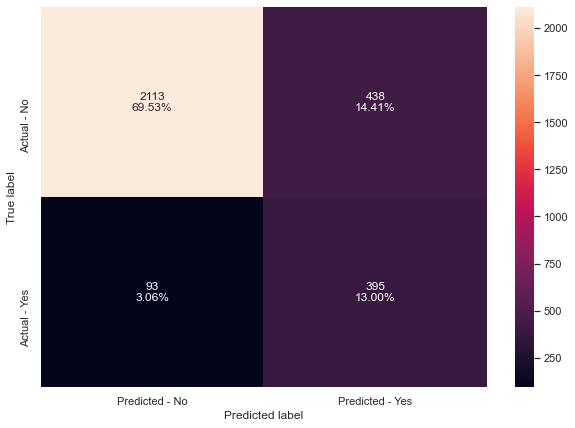

```python
model = LogisticRegression(random_state=1,class_weight="balanced")
lg = model.fit(X_train1,y_train1)

# creating confusion matrix
make_confusion_matrix(lg,X_test1,y_test1)

# checking model performance
scores_LR = get_metrics_score(lg,X_train1,X_test1,y_train1,y_test1,flag=True)
```

Recall is good however the accuracy and precission are very low

## Training set

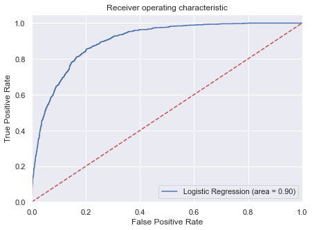

```python
logit_roc_auc_train = roc_auc_score(y_train1, lg.predict_proba(X_train1)[:,1])
fpr, tpr, thresholds = roc_curve(y_train1, lg.predict_proba(X_train1)[:,1])
plt.figure(figsize=(7,5))
plt.plot(fpr, tpr, label='Logistic Regression (area = %0.2f)' % logit_roc_auc_train)
plt.plot([0, 1], [0, 1],'r--')
plt.xlim([0.0, 1.0])
plt.ylim([0.0, 1.05])
plt.xlabel('False Positive Rate')
plt.ylabel('True Positive Rate')
plt.title('Receiver operating characteristic')
plt.legend(loc="lower right")
plt.show()
```

## Testing Set

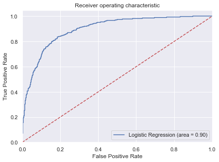

```python
logit_roc_auc_test = roc_auc_score(y_test1, lg.predict_proba(X_test1)[:,1])
fpr, tpr, thresholds = roc_curve(y_test1, lg.predict_proba(X_test1)[:,1])
plt.figure(figsize=(7,5))
plt.plot(fpr, tpr, label='Logistic Regression (area = %0.2f)' % logit_roc_auc_test)
plt.plot([0, 1], [0, 1],'r--')
plt.xlim([0.0, 1.0])
plt.ylim([0.0, 1.05])
plt.xlabel('False Positive Rate')
plt.ylabel('True Positive Rate')
plt.title('Receiver operating characteristic')
plt.legend(loc="lower right")
plt.show()
```

The model is generalising well on Training and Test sets

## Finding Coefficients

```python
log_odds = lg.coef_[0]
pd.options.display.float_format = '{:.5f}'.format
pd.DataFrame(log_odds, X_train1.columns, columns=['coef']).T
```

|  | Customer_Age | Dependent_count | Months_on_book | Total_Relationship_Count | Months_Inactive_12_mon | Contacts_Count_12_mon | Credit_Limit | Total_Revolving_Bal | Avg_Open_To_Buy | Total_Amt_Chng_Q4_Q1 | Total_Trans_Amt | Total_Trans_Ct | Total_Ct_Chng_Q4_Q1 | Avg_Utilization_Ratio | Gender_M | Education_Level_Doctorate | Education_Level_Graduate | Education_Level_High School | Education_Level_Post-Graduate | Education_Level_Uneducated | Income_Category_$40K - $60K | Income_Category_$60K - $80K | Income_Category_$80K - $120K | Income_Category_Less than $40K | Marital_Status_Married | Marital_Status_Single | Card_Category_Gold | Card_Category_Platinum | Card_Category_Silver |
| --- | --- | --- | --- | --- | --- | --- | --- | --- | --- | --- | --- | --- | --- | --- | --- | --- | --- | --- | --- | --- | --- | --- | --- | --- | --- | --- | --- | --- | --- |
| coef | 0.04098 | 0.44809 | -0.00076 | -0.23460 | 0.51445 | 0.69214 | -0.00026 | -0.00051 | 0.00025 | 0.00564 | 0.00047 | -0.11540 | -0.08351 | 0.01259 | -0.05588 | 0.01532 | 0.02533 | -0.00050 | 0.02048 | 0.02437 | 0.01864 | -0.03183 | -0.00629 | 0.11255 | -0.04494 | 0.12131 | 0.01310 | 0.00211 | 0.00166 |

## odds from Coefficients

```python
odds = np.exp(lg.coef_[0]) # converting coefficients to odds
pd.set_option('display.max_columns',None)  # removing limit from number of columns to display
pd.DataFrame(odds, X_train1.columns, columns=['odds']).T # adding the odds to a dataframe
```

|  | Customer_Age | Dependent_count | Months_on_book | Total_Relationship_Count | Months_Inactive_12_mon | Contacts_Count_12_mon | Credit_Limit | Total_Revolving_Bal | Avg_Open_To_Buy | Total_Amt_Chng_Q4_Q1 | Total_Trans_Amt | Total_Trans_Ct | Total_Ct_Chng_Q4_Q1 | Avg_Utilization_Ratio | Gender_M | Education_Level_Doctorate | Education_Level_Graduate | Education_Level_High School | Education_Level_Post-Graduate | Education_Level_Uneducated | Income_Category_$40K - $60K | Income_Category_$60K - $80K | Income_Category_$80K - $120K | Income_Category_Less than $40K | Marital_Status_Married | Marital_Status_Single | Card_Category_Gold | Card_Category_Platinum | Card_Category_Silver |
| --- | --- | --- | --- | --- | --- | --- | --- | --- | --- | --- | --- | --- | --- | --- | --- | --- | --- | --- | --- | --- | --- | --- | --- | --- | --- | --- | --- | --- | --- |
| odds | 1.04183 | 1.56532 | 0.99924 | 0.79089 | 1.67272 | 1.99798 | 0.99974 | 0.99949 | 1.00025 | 1.00566 | 1.00047 | 0.89101 | 0.91988 | 1.01266 | 0.94565 | 1.01544 | 1.02565 | 0.99950 | 1.02069 | 1.02467 | 1.01882 | 0.96867 | 0.99373 | 1.11913 | 0.95605 | 1.12898 | 1.01319 | 1.00211 | 1.00166 |

## Percentage change in odds

```python
perc_change_odds = (np.exp(lg.coef_[0])-1)*100 # finding the percentage change
pd.set_option('display.max_columns',None) # removing limit from number of columns to display
pd.DataFrame(perc_change_odds, X_train1.columns, columns=['change_odds%']).T # adding the change_odds% to a dataframe
```

|  | Customer_Age | Dependent_count | Months_on_book | Total_Relationship_Count | Months_Inactive_12_mon | Contacts_Count_12_mon | Credit_Limit | Total_Revolving_Bal | Avg_Open_To_Buy | Total_Amt_Chng_Q4_Q1 | Total_Trans_Amt | Total_Trans_Ct | Total_Ct_Chng_Q4_Q1 | Avg_Utilization_Ratio | Gender_M | Education_Level_Doctorate | Education_Level_Graduate | Education_Level_High School | Education_Level_Post-Graduate | Education_Level_Uneducated | Income_Category_$40K - $60K | Income_Category_$60K - $80K | Income_Category_$80K - $120K | Income_Category_Less than $40K | Marital_Status_Married | Marital_Status_Single | Card_Category_Gold | Card_Category_Platinum | Card_Category_Silver |
| --- | --- | --- | --- | --- | --- | --- | --- | --- | --- | --- | --- | --- | --- | --- | --- | --- | --- | --- | --- | --- | --- | --- | --- | --- | --- | --- | --- | --- | --- |
| change_odds% | 4.18336 | 56.53198 | -0.07610 | -20.91105 | 67.27187 | 99.79785 | -0.02567 | -0.05111 | 0.02545 | 0.56581 | 0.04733 | -10.89906 | -8.01215 | 1.26646 | -5.43506 | 1.54354 | 2.56485 | -0.05016 | 2.06930 | 2.46688 | 1.88196 | -3.13316 | -0.62728 | 11.91296 | -4.39465 | 12.89759 | 1.31869 | 0.21130 | 0.16606 |

### Coefficient interpretations

- Dependent_count: Holding all other features constant a 1 unit change in dependent_count will increase the odds of a customer attriting by 56.53% increase in the odds.
- Months_Inactive_12_mon: Holding all other features constant a 1 unit change in Months_Inactive_12_mon will increase the odds of attriting by 67.27% increase in the odds.
- Contact_Count_12_mon: Holding all other features constant a 1 unit change in contacts_count_12_mon will increase the odds of a customer attriting by 99.79% increase in the odds.
- Total_Relationship_Count: Holding all other features constant a 1 unit change in the Total_Relationship_count will decrease the odds of a customer attriting by 20.9%

## improving the model

```python
# Optimal threshold as per AUC-ROC curve
# The optimal cut off would be where tpr is high and fpr is low
fpr, tpr, thresholds = metrics.roc_curve(y_test1, lg.predict_proba(X_test1)[:,1])

optimal_idx = np.argmax(tpr - fpr)
optimal_threshold_auc_roc = thresholds[optimal_idx]
print(optimal_threshold_auc_roc)
```

```
0.4654376630981366
```

```python
scores_LR = get_metrics_score(lg,X_train1,X_test1,y_train1,y_test1,threshold=optimal_threshold_auc_roc,roc=True)
```

```
Accuracy on training set :  0.8072799097065463
Accuracy on test set :  0.8173741362290227
Recall on training set :  0.8533801580333626
Recall on test set :  0.8340163934426229
Precision on training set :  0.44771994472593274
Precision on test set :  0.4619750283768445
F1 on training set :  0.5873111782477342
F1 on test set :  0.5945945945945946
ROC-AUC Score on training set :  0.8259168398168157
ROC-AUC Score on test set :  0.8241034534833656
```

## Sequential Selector

```python
from mlxtend.feature_selection import SequentialFeatureSelector as SFS

# to plot the performance with addition of each feature
from mlxtend.plotting import plot_sequential_feature_selection as plot_sfs
```

## Creating Dummies

```python
# Separating target variable and other variables
X = df2.drop(columns="Attrition_Flag")
X = pd.get_dummies(X, columns=['Gender','Education_Level','Income_Category','Marital_Status','Card_Category'],drop_first=True)
Y = df2["Attrition_Flag"]
```